# Fantaxtic

Guus Martijn Teunisse

2018-03-22

## Introduction

This is Fantaxtic, a set of wrapper functions for phyloseq and ggplot2 that turns ordinary taxonomic count data into fantaxtic, publication ready plots. Fantaxtic figures come as completely stylized figures with pleasing colors and maximal plotting control. As the output figures are simply ggplot2 objects, expert users can also manipulate the final output to customize figures up to their desire.

## Example: Barplot of relative OTU/ASV abundances

First load the data.

```r
library(fantaxtic)
data(GlobalPatterns)
```

Now subset the data to the 10 most abundants OTUs or ASVs using the `get_top_taxa` function. All other OTUs/ASVs will be collapsed into `"Other"`

```r
ps_tmp <- get_top_taxa(physeq_obj = GlobalPatterns, n = 10, relative = TRUE,
                       discard_other = FALSE, other_label = "Other")
```

Next, create labels for missing taxonomic ranks using the `name_taxa` function.

```r
ps_tmp <- name_taxa(ps_tmp, label = "Unkown", species = T, other_label = "Other")
```

You are now ready to generate a `fantaxtix_bar`! Generate a plot that is colored by Phylum and labeled by Species, coloring the collapsed taxa grey. The output is a translation table of phylum to color, and a `ggplot2` plot.

```r
fantaxtic_bar(ps_tmp, color_by = "Phylum", label_by = "Species", other_label = "Other")
```

```
#>            Level N.color.shades Central.color
#> 2 Actinobacteria              1       #6495ed
#> 3  Bacteroidetes              2       #ff7256
#> 4  Cyanobacteria              3       #edbc64
#> 5     Firmicutes              1       #8470ff
#> 6 Proteobacteria              3       #f4a460
```

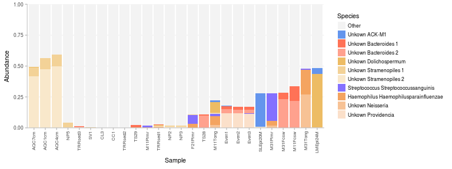

Perhaps a different sample ordering is more meaningful. Let’s order the samples by the abundance of the collapsed category, labeled as “Other”.

```r
fantaxtic_bar(ps_tmp, color_by = "Phylum", label_by = "Family", other_label = "Other",
               order_alg = "other.abnd")
```

```
#>            Level N.color.shades Central.color
#> 2 Actinobacteria              1       #6495ed
#> 3  Bacteroidetes              2       #ff7256
#> 4  Cyanobacteria              3       #edbc64
#> 5     Firmicutes              1       #8470ff
#> 6 Proteobacteria              3       #f4a460
```

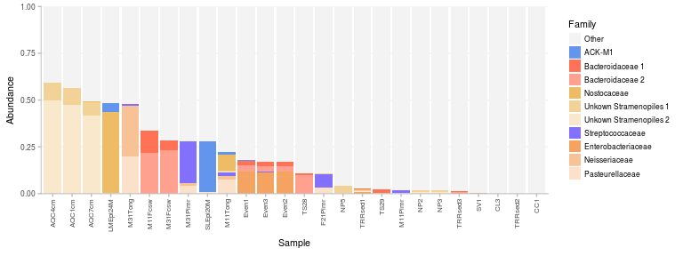

Does the story change when we facet the plot by sample type? Add a faceting factor.

```r
fantaxtic_bar(ps_tmp, color_by = "Phylum", label_by = "Family", facet_by = "SampleType", other_label = "Other")
```

```
#>            Level N.color.shades Central.color
#> 2 Actinobacteria              1       #6495ed
#> 3  Bacteroidetes              2       #ff7256
#> 4  Cyanobacteria              3       #edbc64
#> 5     Firmicutes              1       #8470ff
#> 6 Proteobacteria              3       #f4a460
```

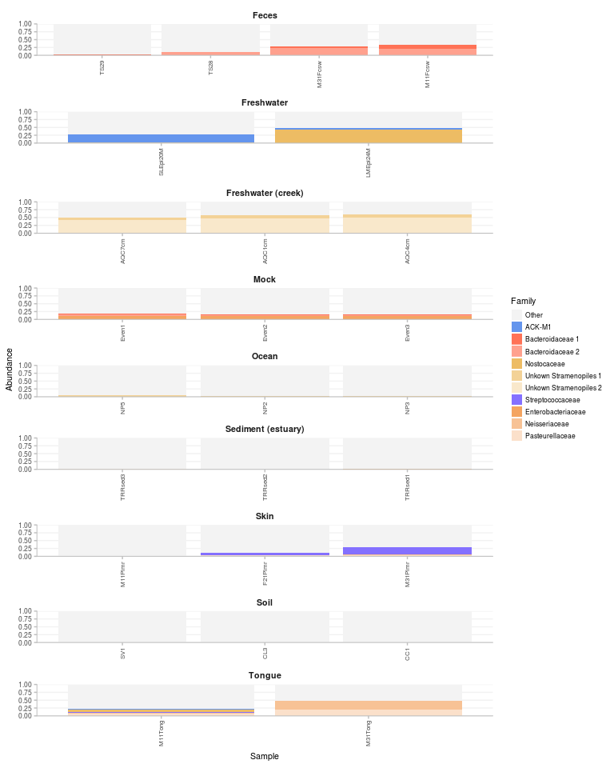